# Reproducible Workflows

## Overview of Reproducible Workflows

In this walkthrough, we will discuss three important components to ensuring reproducible data science workflows:

1. Organizing your project files in a clear and consistent manner
2. Creating reproducible environments to manage package dependencies
   - Using `renv` (for R users) and `conda` (for Python users)
3. Using reproducible reporting tools such as quarto to combine combine code, results, and narrative text

## A Suggested Project Structure

A clear and consistent project structure is essential to keeping organized and facilitating reproducible data science workflows. While there is no one-size-fits-all solution for organizing your project files, the following structure is a suggested starting point and one that we will be using throughout this course.

```
├── data         # store all raw and processed data
├── notebooks    # store all notebooks (.qmd, .Rmd, .ipynb, ...)
├── other        # miscellaneous documents
├── R            # store R functions (ONLY functions)
├── python       # store python functions (ONLY functions)
├── scripts      # store R/python scripts (i.e., non-functions)
├── results      # store all results
├── renv         # do not edit; created automatically by renv (R only)
.Rprofile        # do not edit; created automatically by renv (R only)
renv.lock        # do not edit; created automatically by renv (R only)
environment.yml  # yml file to reproduce conda environment (python only)
conda-lock.yml   # lock file to reproduce conda environment (python only)
```

## Reproducible Environments

Next, to manage package dependencies and ensure that your code can be run on different computers with the same package versions, we will create reproducible environments using `renv` (for R users) and `conda` (for Python users).

**Before proceeding, please ensure that you have pulled the latest version of the `dsip-s26` repository to your computer.**

For this walkthrough, we will be using the files provided in the `dsip-s26/course_materials/cancer_mortality` directory of the `dsip-s26` repository. To follow along, please make a copy of the `dsip-s26/course_materials/cancer_mortality` directory and place it in your `dsip/` directory.

### How to Create a Reproducible Environment

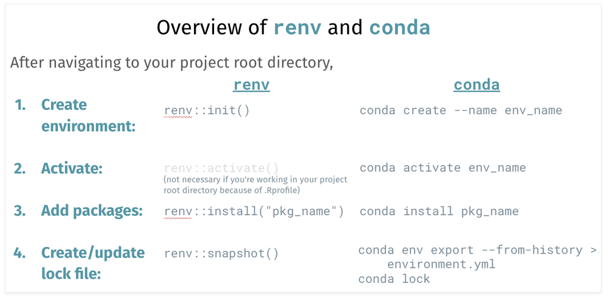

We detail each of these steps below.

**renv (R users)**

0. **Install renv** (only need to run once): If you haven’t already, install the `renv` R package by running the following command in your R console:

   ```r
   install.packages("renv")
   ```

1. **Navigate to your project root directory**:
   - If you are using Positron, open your `dsip/cancer_mortality/` (or `dsip/lab1`) directory.
   - If you are using RStudio, create a new R project in your `dsip/cancer_mortality/` (or `dsip/lab1`) directory. To do this, click on File > New Project > Existing Directory > navigate to your `dsip/cancer_mortality/` (or `dsip/lab1`) directory. This will create a `*.Rproj` file in your project root directory.
2. **Initialize renv**: In the R console, run the following command to initialize an `renv` for your project:

   ```r
   renv::init()
   ```

   > Since we already have R code in our project (see `notebooks/data_cleaning_R.qmd`), `renv` will do its best to automatically detect and install the packages that are being used in your project. If you want to start with a clean slate (i.e., no packages installed), you can run `renv::init(bare = TRUE)` instead.

   **renv Files**

   When you initialize `renv`, this will create several new files/directories: `renv.lock`, `.Rprofile` (a hidden file), and `renv/` in your current working directory. The `renv/` directory contains symbolic links to all of the packages needed/used in your project. [Rather than installing a new copy of the package for every `renv` that you might create, `renv` uses symbolic links that point to your main R package library to save on storage]. The `renv.lock` file (also called the “lockfile”) contains all of the necessary package information to exactly reproduce your R environment on a different computer. Finally, the `.Rprofile` file contains code that is automatically run every time you open R from this working directory; in this case, it contains code to automatically activate your `renv` when you open your project from this directory.
3. **Adding packages**: As you work on your lab, you will need to install new packages. To install/use these packages in your `renv`, you can do so with `renv::install(package_name)`. For example, to render a quarto document, we will need to install the `rmarkdown` package, which can be done by running the following command in your R console:

   ```r
   renv::install("rmarkdown")
   ```

4. **Snapshot your environment**: After you have installed the necessary packages for your lab, you need to “snapshot” your environment, that is, to record the latest package information in your `renv.lock` lockfile. To do this, run the following command in your R console:

   ```r
   renv::snapshot()
   ```

   > To see which packages are being used in your project but not yet installed or snapshotted in the lock file, you can run the following command in your R console: `renv::status()`.
5. **Check your lockfile**: You can open the `renv.lock` file in a text editor to see the package information that has been recorded for your project. This file contains all of the necessary information to exactly reproduce your R environment on a different computer.

**conda (Python users)**

**Windows Users**

If you are on a Windows computer and getting a `conda command not found` error, you must use the `Anaconda Prompt` (not the regular Command Prompt or PowerShell) to run the conda commands below. You can find the Anaconda Prompt by searching for it in the Start Menu.

If you want to integrate conda with PowerShell, you can try following the instructions [here](https://www.codegenes.net/blog/how-can-i-activate-a-conda-environment-from-powershell/).

0. **Install conda-lock** (only need to run once): If you haven’t already, install the `conda-lock` package by running the following command in your terminal:

   ```bash
   conda install --name=base conda-lock
   ```

1. **Navigate to your project root directory**: in your terminal, change your working directory to `dsip/cancer_mortality/` (or `dsip/lab1`), e.g.,

   ```bash
   cd path/to/dsip/cancer_mortality
   ```

2. **Initialize a new conda environment**: To create a new conda environment, run the following command in your terminal. You can replace `dsip_cancer` with the name of your choice for the environment, and you can specify a specific version of Python if desired (e.g., `python=3.12.2`):

   ```bash
   conda create --name dsip_cancer
   ```

   or with a specific version of Python:

   ```bash
   conda create --name dsip_cancer python=3.12.2
   ```

3. **Activate the conda environment**: To activate the conda environment, run the following command in your terminal:

   ```bash
   conda activate dsip_cancer
   ```

   **conda init Error**

   If you run into an error when trying to activate the conda environment, you may need to run the following command to initialize conda in your shell: `conda init` (or or `conda init zsh` if you are using zsh).
4. **Adding packages**: You can add and install new packages in your conda environment using the `conda install` command. For example, the starter python code in `dsip/notebooks/data_cleaning_python.qmd` uses the `pandas` package. We will also need to install the `jupyterlab` package to render quarto notebooks in python. To install these packages, you can run the following command in your terminal:

   ```bash
   conda install pandas jupyterlab
   ```

   > To see which packages are installed in your conda environment, you can run the following command in your terminal: `conda list`.
5. **Export environment**: After you have installed the necessary packages for your lab, you should export your conda environment to a YAML file. This YAML file contains a list of the packages that were installed in your conda environment. To do this, run the following command in your terminal:

   ```bash
   conda env export --from-history > environment.yml
   ```

   > Note: the `--from-history` flag will only list/export the packages that you have explicitly installed in your environment (i.e., it will not include packages that were installed as dependencies of other packages). Be sure to include the `--from-history` flag when exporting your environment to ensure that you have a minimal environment file. If you exclude the `--from-history` flag, you will get a full list of all packages in your environment, including dependencies which may be specific to your operating system and will not be portable to other operating systems.
6. **Create and check conda lock file**: While the above `environment.yml` file is great for sharing your environment with others, it does not provide instructions to *exactly* reproduce your environment across different operating system platforms. To enable exact reproducibility of our conda environment, we need to create a lock file (as we did with `renv`). To create a lock file for your conda environment, you can run the following command in your terminal:

   ```bash
   conda lock
   ```

**Including pip installed dependencies**

If you used pip to install some packages in your conda environment, you can include these pip-installed dependencies in your conda lock file by following the steps below:

### How to Restore Environment from Lock File

Given an appropriate lock file, you can easily reproduce your exact R or Python environment on a different computer by following the instructions below.

**renv (R users)**

0. Clone your `dsip` repository, and install `renv` via `install.packages("renv")` in your R console if you haven’t already.
1. **Navigate to your project root directory**:
   - If you are using Positron, open your `dsip/lab1/` directory.
   - If you are using RStudio, open your `*.Rproj` project file in your `dsip/lab1/` directory.
2. **Restore your environment**: To restore your R environment to the exact state that it was in when you last worked on it, you can run the following command in your R console:

   ```r
   renv::restore()
   ```

**conda (Python users)**

0. Clone your `dsip` repository, and install `conda-lock` via `conda install --name=base conda-lock` in your terminal if you haven’t already.
1. **Navigate to your project root directory**: Open your terminal and navigate to your `dsip/lab1/` directory, e.g.,

   ```bash
   cd path/to/dsip/lab1
   ```

2. **Restore your environment**: To restore your Python environment using the conda-lock file, you can run the following command in your terminal:

   ```bash
   conda-lock install --name dsip_lab1
   ```

## Reproducible Reporting with Quarto

As discussed in a different tutorial, **quarto** is a powerful tool for creating reproducible reports that combine code, results, and narrative text. Using quarto in conjunction with reproducible environments will ensure that your reports can be easily reproduced on different computers with the same package versions.

*Note:* If you are using quarto in Positron or VS Code, I would highly recommend installing the quarto extension for your IDE to make working with quarto documents much easier. To open the Extensions view, you can click on the square icon on the left side or press `Ctrl+Shift+X` (`Cmd+Shift+X` on Mac). Then, search for “Quarto” and click on the install button. (This step only needs to be done once.)

Now to render a quarto document within a reproducible environment:

**R (VS Code/Positron)**

0. Make sure that `rmarkdown` is installed in your `renv`. If not, you can install it via `renv::install("rmarkdown")` in your R console. (Remember to snapshot your environment again via `renv::snapshot()` after installing new packages.)
1. In your terminal, navigate to your project root directory (e.g., `dsip/cancer_mortality/` or `dsip/lab1/`).
2. Render the quarto document using `quarto render` or `quarto preview` in your terminal, e.g.,

   ```bash
   quarto render "notebooks/data_cleaning_R.qmd"
   ```

   or

   ```bash
   quarto preview "notebooks/data_cleaning_R.qmd"
   ```

   **Quarto Preview Button**

   I generally do not recommend using the “Preview” button in Positron to render quarto documents when working within `renv` environments.

   *Why?* This “Preview” button is known to have issues with rendering quarto documents within `renv` environments. In particular, if your `.qmd` file is not in the same directory as your `renv` (e.g., if your `.qmd` file is in a subdirectory such as `notebooks/` like we have done here), the “Preview” button will render your quarto document using your global R environment rather than your project-specific `renv` environment. If you are using the “Preview” button to quickly see your changes, this is ok as long as you are aware of this behavior. However, if you want to check whether or not your quarto document renders correctly within your `renv` environment, you should always use the terminal commands shown above to render/preview your quarto document.

**R (RStudio)**

0. Make sure that `rmarkdown` is installed in your `renv`. If not, you can install it via `renv::install("rmarkdown")` in your R console. (Remember to snapshot your environment again via `renv::snapshot()` after installing new packages.)
1. In RStudio, open your `*.Rproj` project file in your `dsip/cancer_mortality/` (or `dsip/lab1/`) directory. If you successfully opened the project, you should see the name of the project (e.g., `cancer_mortality` or `lab1`) in the top right corner of your RStudio window.
2. Open the quarto document and render it by clicking on the `"Render"` button at the top of the quarto document.

**Python**

0. Make sure that `jupyterlab` is installed in your `conda` environment. If not, you can install it by activating your desired environment (`conda activate <env_name>`) and then running `conda install jupyterlab` in your terminal. (Remember to export your environment again via `conda env export --from-history > environment.yml` and update your lock file via `conda lock` after installing new packages.)

   **VS Code Users**

   If you are using VS Code, you may also need to install the `ipykernel` package in your conda environment to render quarto documents. You can do this by running `conda install ipykernel` in your terminal after activating your desired conda environment.
1. In your terminal, navigate to your project root directory (e.g., `dsip/cancer_mortality/` or `dsip/lab1/`).
2. Render the quarto document using `quarto render` or `quarto preview` in your terminal, e.g.,

   ```bash
   quarto render "notebooks/data_cleaning_python.qmd"
   ```

   or

   ```bash
   quarto preview "notebooks/data_cleaning_python.qmd"
   ```

   **Quarto Preview Button**

   If you are using Positron or VS Code with the quarto extension, you can also use the “Preview” button at the top of the quarto document to render the document. However, you MUST first tell Positron/VS Code which conda environment to use for the quarto document. To do this, open the Command Palette by pressing `Ctrl+Shift+P` (`Cmd+Shift+P` on Mac) and then search for “Python: Select Interpreter”. You can then choose your desired conda environment that you created for lab 1.

   If you do not see your conda environment in the list, you can manually “enter interpreter path” and enter the path to the conda environment (i.e., the path shown next to your desired environment when you run `conda env list` in your terminal).

## Checking Reproducibility

If you would like to check whether or not your project report is fully reproducible, you can try the following steps:

**R**

1. Delete the `renv/library/` and `renv/staging/` directories in your project root directory (e.g., `dsip/lab1/`).
2. For Positron and VS Code users, open your project root directory (e.g., `dsip/lab1/`) in your IDE. For RStudio users, open your `*.Rproj` project file in your project root directory (e.g., `dsip/lab1/`).
3. Try restoring your environment by running the following command in your R console:

   ```r
   renv::restore()
   ```

4. Render your quarto document by running the following command in your terminal, e.g.,

   ```bash
   quarto render "notebooks/lab1.qmd"
   ```

   If the document renders successfully without any errors, then your project is fully reproducible!

**Python**

1. In your terminal, navigate to your project root directory (e.g., `dsip/lab1/`).
2. Create a new conda environment from your lock file by running the following command in your terminal:

   ```bash
   conda-lock install --name <temp_env>
   ```

   *Note:* if the `conda-lock` command is not found, make sure you are using the `base` conda environment (or whatever conda environment you installed `conda-lock` in) by running `conda activate base` (or `conda activate <env_name>`).
3. Render your quarto document using the new conda environment by running the following command in your terminal:

   ```bash
   conda activate <temp_env>
   quarto render "notebooks/lab1.qmd"
   ```

   If the document renders successfully without any errors, then your project is fully reproducible!

**File Paths and External Files**

*Important Note:* When checking reproducibility, make sure that your code does not rely on any absolute file paths (i.e., file paths that are specific to your computer). Instead, use relative file paths that are relative to your project root directory. Additionally, make sure that any external files (e.g., results files or other data files beyond the original data provided to you) that your code relies on have been made available on GitHub.

## Troubleshooting

- If you encounter are trying to render a quarto document and get an error that the `yaml` package is not found, you may need to install the `jupyterlab` package in your conda environment. You can do this by activating your desired conda environment (`conda activate <env_name>`) and then running `conda install jupyterlab` in your terminal. For VS Code users, you may also need to install the `ipykernel` package in your conda environment by running `conda install ipykernel` in your terminal after activating your desired conda environment.
- If `conda-lock` cannot be installed in your base conda environment, this is likely because of version conflicts with other packages in your base environment. To get around this, you can create a temporary conda environment to install `conda-lock` and use it to create lock files for your other conda environments. To do this, run the following commands in your terminal:

  ```bash
  conda create --name temp_conda_lock python=3.12.2
  conda activate temp_conda_lock
  conda install conda-lock
  ```

## Additional Resources

- [Getting Started with renv](https://rstudio.github.io/renv/articles/renv.html)
- [conda Cheat Sheet](https://docs.conda.io/projects/conda/en/4.6.0/_downloads/52a95608c49671267e40c689e0bc00ca/conda-cheatsheet.pdf)